# What Influences Coffee Ratings?

Jana Kassem

2023-09-19

> In this report, we are going to explore a coffee dataset with the variables: Country, Region, Altitude, Year, Bean Color, Bags Produced, and Ratings. The variables were collected from the Coffee Quality Institute’s review pages in 2018. The data contains reviews of the coffee beans from trained reviewers at the Coffee Quality Institute. My chosen outcome variable is the rating from 0-100 each bean got. I will analyze process method, altitude, and year as I test each to determine if they have a direct relationship with the ratings.

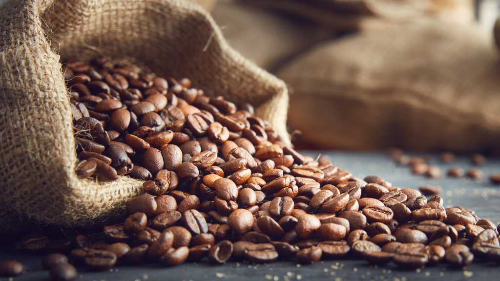

Maxwell, T. (2023, June 16). Coffee. The Best Type of Coffee Beans to Use for Pour-Overs Read More: https://www.tastingtable.com/1316018/best-type-coffee-beans-pour-overs/.

# Distribution of Ratings

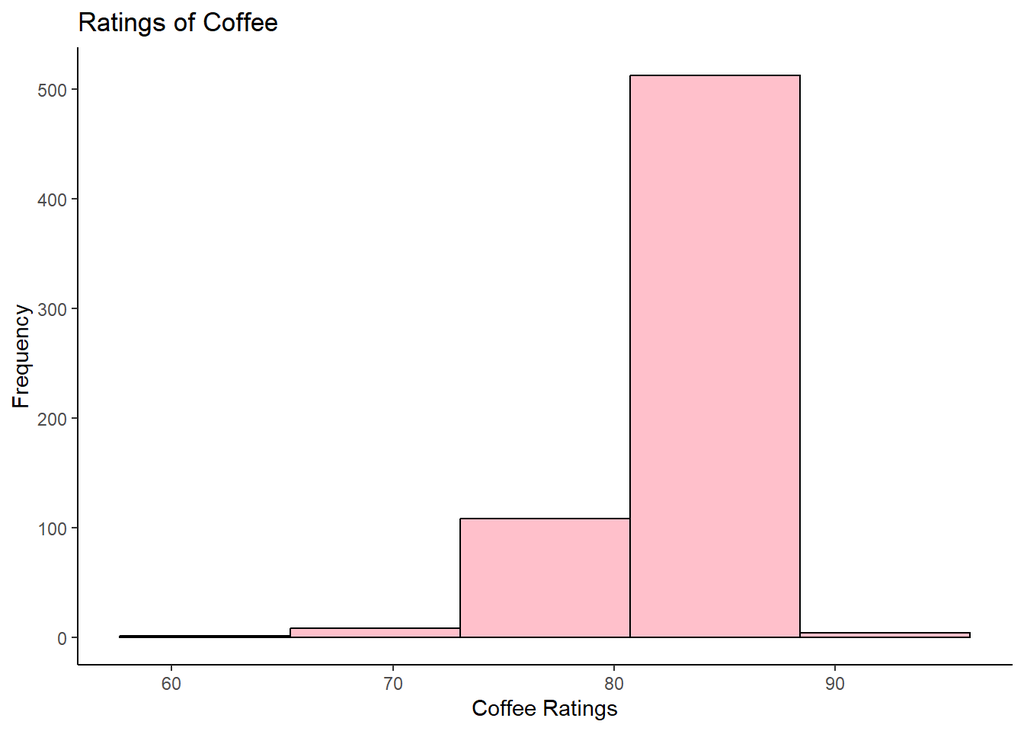

This graph describes the frequency of coffee ratings. It is skewed to the left with a median rating of 82.5. The first quartile is 81.19 and the third quartile is 83.6475.

# Relationship with Process Method

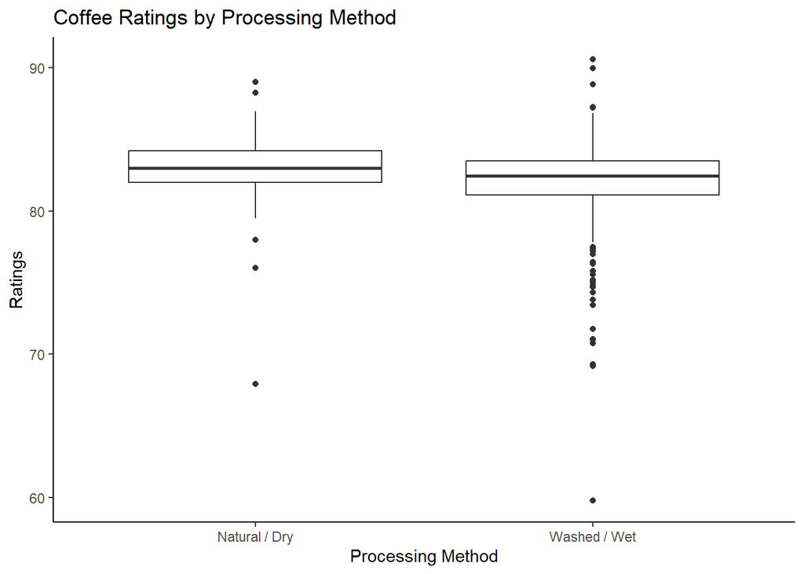

Both distributions are skewed to the left. Natural/dry beans have a mean of 82.92516 and Washed/wet beans have a mean of 82.01479. Natural beans have a median of 83, and washed beans have a median of 82.42. Natural/dry beans have a first quartile of 81.96 and a third quartile of 84.17. Washed/wet beans have a first quartile of 81.125 and a third quartile of 83.5. The Natural/Dry beans have a standard deviation of 2.552341, and the Washed/Wet beans have a standard deviation of 2.723277. Since the means and medians of both distributions are very close we can conclude that the public doesn’t favor one method over the other.

# Relationship with Altitude

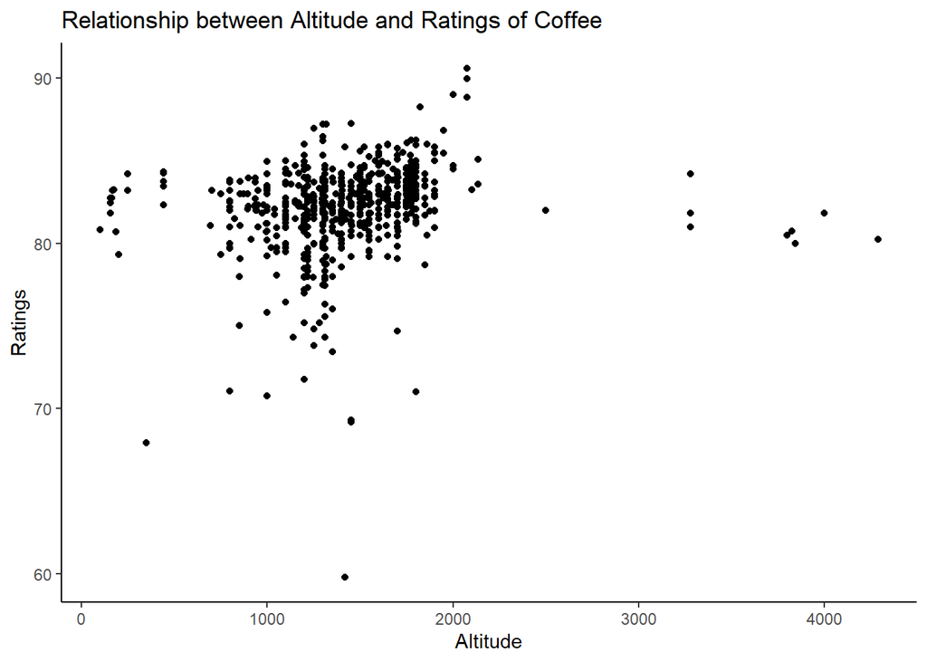

The correlation coefficient of this relationship is 0.1732569 meaning there is no direct correlation between the altitude the coffee beans were produced and their ratings.

# Relationship with Year produced

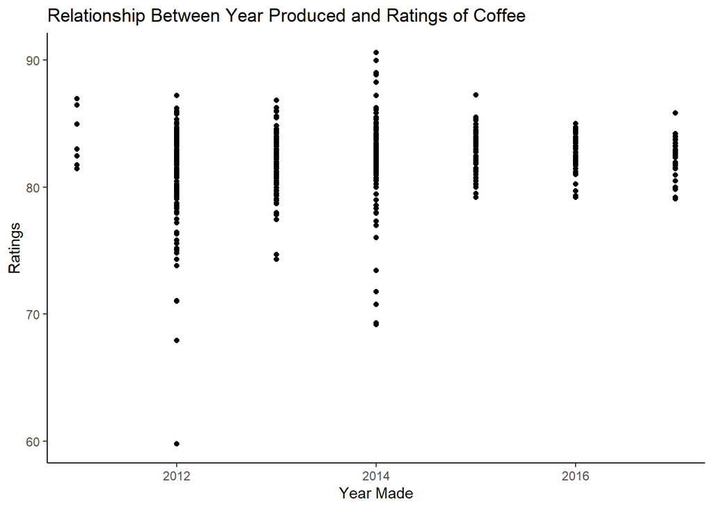

The correlation coefficient of this relationship is 0.0921151 meaning that there is no correlation between the year the coffee was produced and how it was rated professionally.

### References

Donald, Sam. “Coffee Csv File.” CORGIS Datasets Project, corgis-edu.github.io/corgis/csv/coffee/. LeDoux, James. “JLDBC/Coffee-Quality-Database: Building The Coffee Quality Institute Database.” GitHub, github.com/jldbc/coffee-quality-database.